# Práctica Final - Minería de Datos

Juan Luis Serradilla Tormos

2025-05-23

# 1 Resumen ejecutivo

En esta práctica se ha analizado un dataset de contaminación del aire en regiones de Alemania.

Para el preprocesamiento de datos se han eliminado los valores `NA`, duplicados e inválidos, aunque para estos últimos se ha investigando con `aggr` si podían eliminarse. También se ha eliminado directamente la variable `kreis_code` por no aportar información, y la variable `NO2_hrOver200` por tener una varianza muy baja. Este último análisis se ha hecho gracias a nearZeroVar de `caret`. Finalmente, en el análisis descriptivo se ha analizado la distribución de las categorías contaminación baja y alta en todas las variables (numéricas y categóricas), sacando así conclusiones de las características de las zonas con alta y baja contaminación de P2.5. Finalmente, de este análisis descriptivo se ha visto que la variable más relacionada con la contaminación PM10 (con un exceso de esta en las zonas contaminadas), además de que los datos de contaminación se juntan en su gran mayoría en un solo año (2003), y el resto se reparto solo en dos años más (2007 y 2011).

En el entrenamiento de modelos predictivos primero se han seleccionado las variables válidas del dataset y se han balanceado los datos. Se han descartado las variables `kreis`, `year` y `scenario` por no tener capacidad predictiva, de forma que nos quedamos con 9 predictores. Al no tener una alta cantidad de predictores, no se ha hecho una selección de variables, ya que perderíamos información innecesariamente. Luego, para el balanceo de datos se ha hecho un upsampling con SMOTE y un downsampling con selección aleatoria. El upsampling de SMOTE se ha hecho con `UBL` y no con `smotefamily`, ya que permite hacer un upsampling de varias clases a la vez, que era necesario en nuestro caso. Este upsampling y downsampling se ha hecho solo con el conjunto de train, ya que el conjunto te test debe permanecer intacto para representar fielmente la realidad.

# 2 Análisis descriptivo de los datos

Lo primero de todo es cargar los datos y ver cómo son. Al cargar estos datos vamos a importar los `strings` como factores.

```r
# Leemos el archivo CSV
data <- read.csv("data.csv", sep = ";", stringsAsFactors = TRUE)

# Inspeccionamos las características del dataframe
dim(data)
```

```
## [1] 24120    15
```

```r
str(data)
```

```
## 'data.frame':    24120 obs. of  15 variables:
##  $ kreis                : Factor w/ 379 levels "Ahrweiler","Aichach-Friedberg",..: 100 66 215 221 284 369 371 265 325 168 ...
##  $ year                 : int  2019 2019 2019 2019 2019 2019 2019 2019 2019 2019 ...
##  $ NO2_annualMean       : num  16 13.5 25.4 13.4 21 ...
##  $ NO2_hrOver200        : num  0 0.00182 0 0.0017 0.01182 ...
##  $ NO_annualMean        : num  8.02 9.44 12.76 7.6 13.95 ...
##  $ O3_annualMean        : num  55.5 57.8 45.6 57.2 50.1 ...
##  $ O3_daysOver120       : num  6 3.95 0 3.699 0.881 ...
##  $ O3_dailyMaxAnnualMean: num  84.1 79.8 73.7 79.4 75.2 ...
##  $ O3_dailyHourlyMax    : num  218 176 160 176 175 ...
##  $ O3_daily8HrMax       : num  207 160 156 160 158 ...
##  $ PM10_annualMean      : num  12.5 13.8 17.6 14.3 15.7 ...
##  $ PM10_daysOver50      : num  2 1.76 1.74 1.74 1.74 ...
##  $ PM2.5_annualMean     : num  8.33 10.5 11.52 10.5 11.5 ...
##  $ kreis_code           : int  12 68 107 110 122 240 241 281 291 312 ...
##  $ scenario             : Factor w/ 3 levels "average","remote",..: 2 2 2 2 2 2 2 2 2 2 ...
```

```r
head(data)
```

|  | kreis | year | NO2_annualMean | NO2_hrOver200 | NO_annualMean | O3_annualMean | O3_daysOver120 | O3_dailyMaxAnnualMean | O3_dailyHourlyMax | O3_daily8HrMax | PM10_annualMean | PM10_daysOver50 | PM2.5_annualMean | kreis_code | scenario |
| --- | --- | --- | --- | --- | --- | --- | --- | --- | --- | --- | --- | --- | --- | --- | --- |
| 1 | Freiburg im Breisgau | 2019 | 16.01702 | 0.000000000 | 8.020571 | 55.48591 | 6.0000000 | 84.13068 | 218.5000 | 206.9250 | 12.47323 | 2.000000 | 8.332781 | 12 | remote |
| 2 | Dillingen an der Donau | 2019 | 13.48992 | 0.001817585 | 9.441237 | 57.83064 | 3.9495603 | 79.79202 | 175.7353 | 160.3171 | 13.84848 | 1.763275 | 10.495102 | 68 | remote |
| 3 | NÃ¼rnberg | 2019 | 25.38003 | 0.000000000 | 12.756460 | 45.58861 | 0.0000000 | 73.69546 | 160.3441 | 155.6718 | 17.61005 | 1.740177 | 11.517550 | 107 | remote |
| 4 | Neumarkt in der Oberpfalz | 2019 | 13.40075 | 0.001698363 | 7.598587 | 57.19831 | 3.6985046 | 79.41291 | 175.6844 | 160.1654 | 14.30413 | 1.740177 | 10.497852 | 110 | remote |
| 5 | Rosenheim | 2019 | 20.96812 | 0.011816137 | 13.947993 | 50.10122 | 0.8807067 | 75.15788 | 175.1129 | 158.4634 | 15.70417 | 1.740177 | 11.495740 | 122 | remote |
| 6 | Wilhelmshaven | 2019 | 10.79080 | 0.000000000 | 5.827101 | 54.85508 | 0.0000000 | 74.48273 | 184.0290 | 161.8678 | 14.68957 | 1.000000 | 9.892700 | 240 | remote |

- **kreis**: Nombre de la región en la que se ha tomado la medida.
- **year**: Año en el que se ha tomado la medida.
- **NO2_annualMean**: Media anual de partículas de NO2.
- **NO2_hrOver200**: Número de horas al año con una concentración de NO2 superior a 200.
- **NO_annualMean**: Media anual de partículas de NO.
- **O3_annualMean**: Media anual de partículas de O3.
- **O3_daysOver120**: Número de días al año con una concentración de O3 superior a 120.
- **O3_dailyMaxAnnualMean:** Máxima concentración de O3 en un año (medias diarias).
- **O3_dailyHourlyMax**: Máxima concentración de O3 en un año (medias cada hora).
- **O3_daily8HrMax**: Máxima concentración de O3 en un año (medias cada 8 horas).
- **PM10_annualMean**: Media anual de partículas de PM10.
- **PM10_daysOver50**: Número de días al año con una concentración de PM10 superior a 50.
- **PM2.5_annualMean**: Media anual de partículas de PM2.5.
- **kreis_code**: Código de la región en la que se ha tomado la medida.
- **scenario**: Descripción de la zona (`average`, `remote`, `urban`).

De primeras, sabiendo solo esto la única variable que vamos a eliminar es `kreis_code`, ya que aporta la misma información que `kreis`. Además vamos a pasar `year` a factor.

```r
# Eliminamos la variable kreis_code
data$kreis_code <- NULL

# Pasamos year a factor
data$year <- as.factor(data$year)
```

Ahora que hemos limpiado un poco las variables, vamos a ver la cantidad de datos duplicados y nulos que tenemos. En el caso caso de que representen cantidades muy pequeñas del dataset, directamente vamos a eliminarlos.

```r
# Vemos el porcentaje de filas con valores NA
p.rows.na <- sum(rowSums(is.na(data)) > 0) / nrow(data) * 100
p.rows.na
```

```
## [1] 0.1907131
```

```r
# Vemos el porcentaje de filas duplicadas
p.rows.duplicated <- sum(duplicated(data)) / nrow(data) * 100
p.rows.duplicated
```

```
## [1] 0
```

```r
# Como apenas hay filas con valores NA vamos a eliminarlas directamente, ya que no deberían afectar a la distribución de los resultados
data <- na.omit(data)
```

Vemos que no hay duplicados en el dataset y que hay un 0.19% de filas con valores NA, por lo que las hemos eliminado directamente. Ahora que hemos hecho una pequeña limpieza, vamos a inspeccionar más a fondo los datos.

```r
print(dfSummary(data, plain.ascii = FALSE), method = "render")
```

Data Frame Summary

data

**Dimensions**: 24074 x 14  
**Duplicates**: 0

| **No** | **Variable** | **Stats / Values** | **Freqs (% of Valid)** | **Graph** | **Valid** | **Missing** |
| --- | --- | --- | --- | --- | --- | --- |
| 1 | kreis [factor] | 1. Ahrweiler 2. Aichach-Friedberg 3. Alb-Donau-Kreis 4. AltÃ¶tting 5. Altenburger Land 6. Altenkirchen (Westerwald) 7. Altmarkkreis Salzwedel 8. Alzey-Worms 9. Amberg 10. Amberg-Sulzbach [ 369 others … | 60 ( 0.2% ) 60 ( 0.2% ) 60 ( 0.2% ) 60 ( 0.2% ) 60 ( 0.2% ) 60 ( 0.2% ) 60 ( 0.2% ) 60 ( 0.2% ) 60 ( 0.2% ) 60 ( 0.2% ) 23474 ( 97.5% ) |  | 24074 (100.0%) | 0 (0.0%) |
| 2 | year [factor] | 1. 2003 2. 2004 3. 2005 4. 2006 5. 2007 6. 2008 7. 2009 8. 2010 9. 2011 10. 2012 [ 10 others ] | 1200 ( 5.0% ) 1204 ( 5.0% ) 1204 ( 5.0% ) 1206 ( 5.0% ) 1204 ( 5.0% ) 1206 ( 5.0% ) 1204 ( 5.0% ) 1206 ( 5.0% ) 1203 ( 5.0% ) 1206 ( 5.0% ) 12031 ( 50.0% ) |  | 24074 (100.0%) | 0 (0.0%) |
| 3 | NO2_annualMean [numeric] | Mean (sd) : 17.2 (6.4) min ≤ med ≤ max: 0.2 ≤ 16.4 ≤ 45.4 IQR (CV) : 7.5 (0.4) | 17641 distinct values |  | 24074 (100.0%) | 0 (0.0%) |
| 4 | NO2_hrOver200 [numeric] | Mean (sd) : 0 (0.1) min ≤ med ≤ max: 0 ≤ 0 ≤ 3 IQR (CV) : 0 (8.9) | 11740 distinct values |  | 24074 (100.0%) | 0 (0.0%) |
| 5 | NO_annualMean [numeric] | Mean (sd) : 8.6 (6.1) min ≤ med ≤ max: -3.1 ≤ 7.3 ≤ 62.1 IQR (CV) : 6.2 (0.7) | 17645 distinct values |  | 24074 (100.0%) | 0 (0.0%) |
| 6 | O3_annualMean [numeric] | Mean (sd) : 51 (7.1) min ≤ med ≤ max: 11.3 ≤ 50.8 ≤ 96.7 IQR (CV) : 6.9 (0.1) | 17364 distinct values |  | 24074 (100.0%) | 0 (0.0%) |
| 7 | O3_daysOver120 [numeric] | Mean (sd) : 1.5 (2.4) min ≤ med ≤ max: 0 ≤ 1 ≤ 45 IQR (CV) : 2 (1.6) | 14906 distinct values |  | 24074 (100.0%) | 0 (0.0%) |
| 8 | O3_dailyMaxAnnualMean [numeric] | Mean (sd) : 75.7 (3.8) min ≤ med ≤ max: 53.9 ≤ 75.6 ≤ 107.3 IQR (CV) : 3.4 (0.1) | 20576 distinct values |  | 24074 (100.0%) | 0 (0.0%) |
| 9 | O3_dailyHourlyMax [numeric] | Mean (sd) : 175.1 (11.4) min ≤ med ≤ max: 76.1 ≤ 175.1 ≤ 313.6 IQR (CV) : 0.7 (0.1) | 20448 distinct values |  | 24074 (100.0%) | 0 (0.0%) |
| 10 | O3_daily8HrMax [numeric] | Mean (sd) : 158.6 (9.3) min ≤ med ≤ max: 71.9 ≤ 158.6 ≤ 249.5 IQR (CV) : 1.8 (0.1) | 20553 distinct values |  | 24074 (100.0%) | 0 (0.0%) |
| 11 | PM10_annualMean [numeric] | Mean (sd) : 17.9 (3.7) min ≤ med ≤ max: 3.9 ≤ 17.7 ≤ 37.1 IQR (CV) : 4.7 (0.2) | 18140 distinct values |  | 24074 (100.0%) | 0 (0.0%) |
| 12 | PM10_daysOver50 [numeric] | Mean (sd) : 7.6 (6.9) min ≤ med ≤ max: -0.6 ≤ 6 ≤ 78 IQR (CV) : 8.8 (0.9) | 13897 distinct values |  | 24074 (100.0%) | 0 (0.0%) |
| 13 | PM2.5_annualMean [numeric] | Mean (sd) : 12.2 (6.3) min ≤ med ≤ max: -59.3 ≤ 12.6 ≤ 147 IQR (CV) : 2.9 (0.5) | 19096 distinct values |  | 24074 (100.0%) | 0 (0.0%) |
| 14 | scenario [factor] | 1. average 2. remote 3. urban | 8023 ( 33.3% ) 8025 ( 33.3% ) 8026 ( 33.3% ) |  | 24074 (100.0%) | 0 (0.0%) |

Generated by summarytools 1.1.4 ([R](https://www.r-project.org/) version 4.5.0)  
2025-05-23

Al analizar el resumen del dataset podemos ver que hay algunas variables numéricas con valores negativos. Sin embargo, estas variables son concentraciones de partículas y conteo de horas o días, por lo que los valores negativos no tienen sentido dada su definición matemática. Estas variables son: `NO_annualMean`, `PM10_daysOver50`, `PM2.5_annualMean`. Vamos a ver si podemos eliminar estos valores negativos.

```r
# Seleccioamos las variables que queremos inspeccionar
data.vars <- data %>% select(NO_annualMean, PM10_daysOver50, PM2.5_annualMean)

# Seleccionamos las filas con valores negativos
data.vars.neg <- data.vars %>% filter(NO_annualMean < 0 | PM10_daysOver50 < 0 | PM2.5_annualMean < 0)

# Vemos el porcentaje de filas con valores negativos
p.rows.neg <- nrow(data.vars.neg) / (nrow(data) - nrow(data.vars.neg)) * 100
p.rows.neg
```

```
## [1] 2.38156
```

Se puede observar como los valores negativos representan un 2.38% del dataframe. Esto es bastante más que el 0.19% que suponían los valores NA, por lo que en vez de eliminarlos vamos a usar el paquete `VIM` para ver si podemos imputar estos valores. Vamos a convertir estos valores a `NA` y luego observar su distribución con `aggr`.

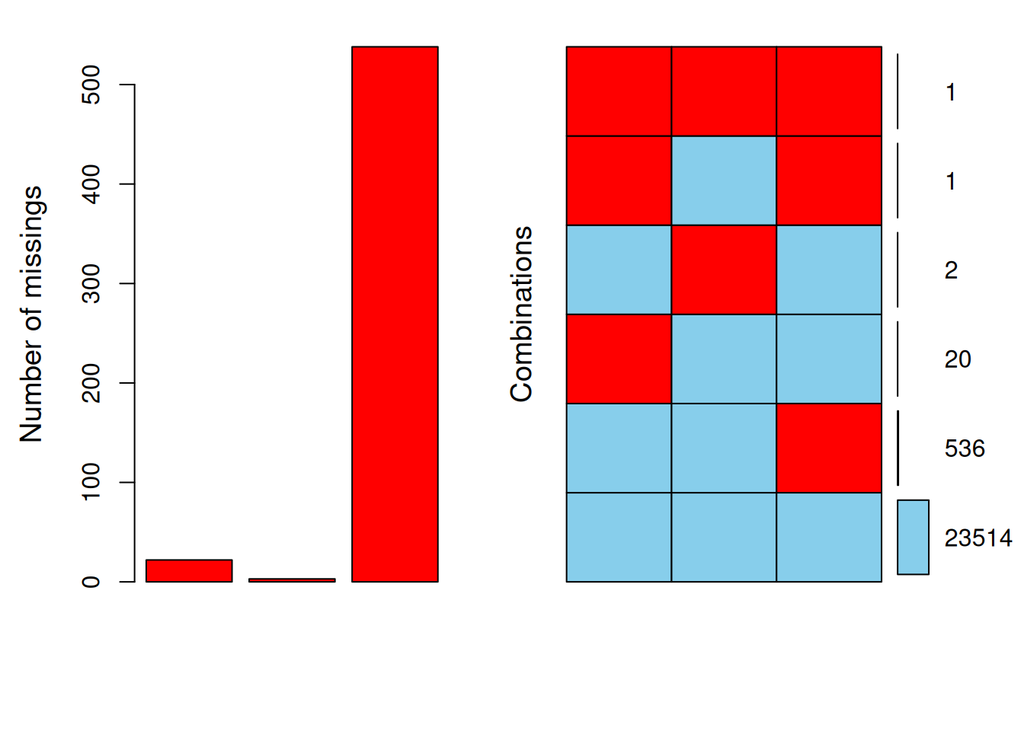

```r
# Convertimos los valores negativos en NA
data$NO_annualMean[data$NO_annualMean < 0] <- NA
data$PM10_daysOver50[data$PM10_daysOver50 < 0] <- NA
data$PM2.5_annualMean[data$PM2.5_annualMean < 0] <- NA

# Usamos el paquete VIM para ver si se puede hacer algo con los valores NA
data.plot <- data %>% select(NO_annualMean, PM10_daysOver50, PM2.5_annualMean)
aggr(data.plot, numbers = TRUE, prop = FALSE)
```

Se puede ver en el gráfico que más del 95% de los valores negativos pertenecen a `P2.5_annualMean`. Como esta va a ser la variable objetivo a lo largo de la práctica no vamos a imputar estos valores, ya que no queremos generar muestras sintéticas que afecten a las predicciones. Como los valores negativos fuera de esta variable son realmente escasos, vamos a eliminarlos directamente. Luego volveremos a ver la distribución del dataset.

```r
# Eliminamos las filas con N
data <- na.omit(data)

# Volvemos a ver el resumen estadístico
print(dfSummary(data, plain.ascii = FALSE), method = "render")
```

Data Frame Summary

data

**Dimensions**: 23514 x 14  
**Duplicates**: 0

| **No** | **Variable** | **Stats / Values** | **Freqs (% of Valid)** | **Graph** | **Valid** | **Missing** |
| --- | --- | --- | --- | --- | --- | --- |
| 1 | kreis [factor] | 1. Ahrweiler 2. Aichach-Friedberg 3. Alb-Donau-Kreis 4. AltÃ¶tting 5. Altenburger Land 6. Altenkirchen (Westerwald) 7. Altmarkkreis Salzwedel 8. Alzey-Worms 9. Amberg 10. Amberg-Sulzbach [ 369 others … | 57 ( 0.2% ) 57 ( 0.2% ) 57 ( 0.2% ) 57 ( 0.2% ) 57 ( 0.2% ) 57 ( 0.2% ) 60 ( 0.3% ) 57 ( 0.2% ) 57 ( 0.2% ) 57 ( 0.2% ) 22941 ( 97.6% ) |  | 23514 (100.0%) | 0 (0.0%) |
| 2 | year [factor] | 1. 2003 2. 2004 3. 2005 4. 2006 5. 2007 6. 2008 7. 2009 8. 2010 9. 2011 10. 2012 [ 10 others ] | 669 ( 2.8% ) 1201 ( 5.1% ) 1201 ( 5.1% ) 1203 ( 5.1% ) 1197 ( 5.1% ) 1203 ( 5.1% ) 1201 ( 5.1% ) 1206 ( 5.1% ) 1200 ( 5.1% ) 1204 ( 5.1% ) 12029 ( 51.2% ) |  | 23514 (100.0%) | 0 (0.0%) |
| 3 | NO2_annualMean [numeric] | Mean (sd) : 17.1 (6.3) min ≤ med ≤ max: 0.2 ≤ 16.4 ≤ 45.4 IQR (CV) : 7.5 (0.4) | 17210 distinct values |  | 23514 (100.0%) | 0 (0.0%) |
| 4 | NO2_hrOver200 [numeric] | Mean (sd) : 0 (0.1) min ≤ med ≤ max: 0 ≤ 0 ≤ 3 IQR (CV) : 0 (9) | 11417 distinct values |  | 23514 (100.0%) | 0 (0.0%) |
| 5 | NO_annualMean [numeric] | Mean (sd) : 8.6 (6.1) min ≤ med ≤ max: 0 ≤ 7.2 ≤ 62.1 IQR (CV) : 6.3 (0.7) | 17216 distinct values |  | 23514 (100.0%) | 0 (0.0%) |
| 6 | O3_annualMean [numeric] | Mean (sd) : 50.9 (7) min ≤ med ≤ max: 11.3 ≤ 50.8 ≤ 96.7 IQR (CV) : 6.9 (0.1) | 16943 distinct values |  | 23514 (100.0%) | 0 (0.0%) |
| 7 | O3_daysOver120 [numeric] | Mean (sd) : 1.5 (2.4) min ≤ med ≤ max: 0 ≤ 1 ≤ 45 IQR (CV) : 2 (1.6) | 14382 distinct values |  | 23514 (100.0%) | 0 (0.0%) |
| 8 | O3_dailyMaxAnnualMean [numeric] | Mean (sd) : 75.6 (3.8) min ≤ med ≤ max: 53.9 ≤ 75.6 ≤ 107.3 IQR (CV) : 3.4 (0.1) | 20022 distinct values |  | 23514 (100.0%) | 0 (0.0%) |
| 9 | O3_dailyHourlyMax [numeric] | Mean (sd) : 175.1 (11.5) min ≤ med ≤ max: 76.1 ≤ 175.1 ≤ 313.6 IQR (CV) : 0.7 (0.1) | 19896 distinct values |  | 23514 (100.0%) | 0 (0.0%) |
| 10 | O3_daily8HrMax [numeric] | Mean (sd) : 158.6 (9.4) min ≤ med ≤ max: 71.9 ≤ 158.6 ≤ 249.5 IQR (CV) : 1.8 (0.1) | 20000 distinct values |  | 23514 (100.0%) | 0 (0.0%) |
| 11 | PM10_annualMean [numeric] | Mean (sd) : 17.8 (3.6) min ≤ med ≤ max: 3.9 ≤ 17.7 ≤ 37.1 IQR (CV) : 4.6 (0.2) | 17681 distinct values |  | 23514 (100.0%) | 0 (0.0%) |
| 12 | PM10_daysOver50 [numeric] | Mean (sd) : 7.3 (6.5) min ≤ med ≤ max: 0 ≤ 5.9 ≤ 78 IQR (CV) : 8.4 (0.9) | 13495 distinct values |  | 23514 (100.0%) | 0 (0.0%) |
| 13 | PM2.5_annualMean [numeric] | Mean (sd) : 12.8 (4.8) min ≤ med ≤ max: 0 ≤ 12.7 ≤ 147 IQR (CV) : 2.6 (0.4) | 18894 distinct values |  | 23514 (100.0%) | 0 (0.0%) |
| 14 | scenario [factor] | 1. average 2. remote 3. urban | 7838 ( 33.3% ) 7838 ( 33.3% ) 7838 ( 33.3% ) |  | 23514 (100.0%) | 0 (0.0%) |

Generated by summarytools 1.1.4 ([R](https://www.r-project.org/) version 4.5.0)  
2025-05-23

Vemos que los valores de las variables categóricas están equilibrados, y que los valores de las variables numéricas en general son razonables. Sin embargo, hay algunos predictores numéricos que parece que tienen poca variabilidad. Vamos a analizar con `nearZeroVar` de caret si hace falta eliminar alguna de estas variables debido a una baja varianza.

```r
# Seleccionamos las variables numéricas
data.num <- data %>% select_if(is.numeric)

# Analizamos la variabilidad de las variables numéricas
data.nzv <- nearZeroVar(data.num, saveMetrics = TRUE)
data.nzv
```

|  | freqRatio | percentUnique | zeroVar | nzv |
| --- | --- | --- | --- | --- |
| NO2_annualMean | 2.000000 | 73.19044 | FALSE | FALSE |
| NO2_hrOver200 | 250.666667 | 48.55405 | FALSE | FALSE |
| NO_annualMean | 1.500000 | 73.21596 | FALSE | FALSE |
| O3_annualMean | 1.500000 | 72.05495 | FALSE | FALSE |
| O3_daysOver120 | 11.009188 | 61.16356 | FALSE | FALSE |
| O3_dailyMaxAnnualMean | 1.000000 | 85.14927 | FALSE | FALSE |
| O3_dailyHourlyMax | 1.200000 | 84.61342 | FALSE | FALSE |
| O3_daily8HrMax | 1.666667 | 85.05571 | FALSE | FALSE |
| PM10_annualMean | 2.000000 | 75.19350 | FALSE | FALSE |
| PM10_daysOver50 | 1.253283 | 57.39134 | FALSE | FALSE |

[output cut: 1 more lines]

La métrica `freqRatio` nos indica la frecuencia de la variable más común sobre la segunda más común, es decir, si la variable más común tiene una frecuencia de 100 y la segunda más común de 25, este ratio será 4. Por otro lado, la métrica `percentUnique` nos indica el porcentaje de valores únicos sobre el total de valores, ayudándonos a ver si una variable es continua (porcentaje alto) o es prácticamente constante (porcentaje bajo).

Podemos ver en los resultados que hay dos variables con un `freqRatio` muy alto: `NO2_hrOver200` y `O3_daysOver120`, aunque la primera es mucho mayor a la segunda. De primeras esto es un mal indicativo, sin embargo, las dos variables tienen un `percentUnique` alto, por lo que el algoritmo no las clasifica con `TRUE` en `nzv`. La segunda variable tiene un `freqRatio` de 11, que junto a su alto `percentUnique` de 62 indica que es una variable válida. Por otro lado, la primera variable tiene un `freqRatio` enorme en comparación con el resto (de 250) y, aunque tenga un `percentUnique` del 48.6 (lo cual no es bajo), sí que es mucho menor que el siguiente valor más pequeño (57.4), de casi 10 puntos menos. Por lo tanto, vamos a eliminar del dataset la variable `NO2_hrOver200`.

```r
# Eliminamos la variable "NO2_hrOver200"
data$NO2_hrOver200 <- NULL
```

Ahora, vamos a responder a las preguntas:

- “¿Cuáles son las características de las zonas con alta contaminación por PM2.5?”
- “¿Cuáles son las características de las zonas con baja contaminación por PM2.5?”

```r
# Creamos una nueva variable que indique el nivel de contaminación de forma categórica
data$contamination <- cut(
    data$PM2.5_annualMean,
    breaks = c(-Inf, 10, 25, 50, Inf),
    labels = c("Bajo", "Moderada", "Insalubre", "Muy Insalubre")
)

# Creamos una nueva variable que indique si la contaminacion es alta o baja
data$contamination_2levels <- ifelse(data$PM2.5_annualMean > 25, "Alta", "Baja")
data$contamination_2levels <- as.factor(data$contamination_2levels)

# Vemos el resumen estadístico de las nuevas variables
table(data$contamination)
```

```
##
##          Bajo      Moderada     Insalubre Muy Insalubre
##          3974         19288           174            78
```

```r
table(data$contamination_2levels)
```

```
##
##  Alta  Baja
##   252 23262
```

Ahora que tenemos la variable categórica, vamos a ver las distribuciones de las variables numéricas en función del nivel de contaminación. También vamos a ver la distribución de las variables categóricas (año y scenario) en función del nivel de contaminación, buscando alguna relación.

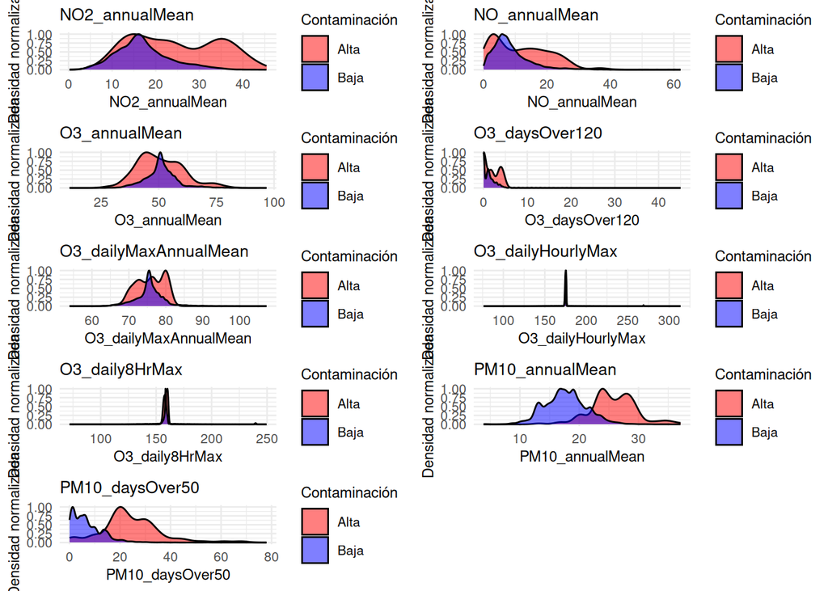

```r
# Creamos una lista con los nombres de las variables numéricas
data.num.vars <- names(data)[sapply(data, is.numeric)]
data.num.vars <- setdiff(data.num.vars, "PM2.5_annualMean")

# Realizamos un histograma para cada variable numérica en el cual se vea su distribución según el nivel de contaminación.
densities <- lapply(data.num.vars, function(var) {
    ggplot(data, aes(
        x     = .data[[var]],
        fill  = contamination_2levels,
        group = contamination_2levels
    )) +
        geom_density(
            aes(y = after_stat(..scaled..)),
            alpha = 0.5,
            position = "identity"
        ) +
        scale_fill_manual(
            name   = "Contaminación",
            values = c("Baja" = "blue", "Alta" = "red")
        ) +
        labs(
            title = var,
            x     = var,
            y     = "Densidad normalizada"
        ) +
        theme_minimal(base_size = 10) +
        theme(
            plot.title   = element_text(size = 10),
            axis.title   = element_text(size = 9),
            axis.text    = element_text(size = 8),
            legend.title = element_text(size = 9),
            legend.text  = element_text(size = 8)
        )
})
do.call(grid.arrange, c(densities, ncol = 2))
```

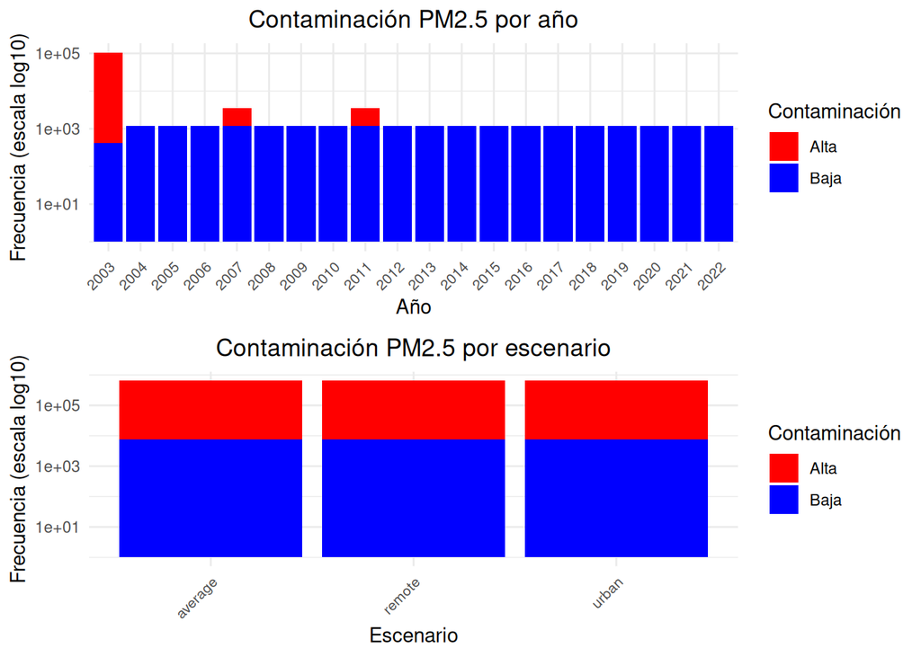

```r
# Creamos una lista con los nombres de las variables categóricas
data.cat.vars <- c("year", "scenario")

p_year <- ggplot(data, aes(x = factor(year), fill = contamination_2levels)) +
    geom_bar(position = "stack") +
    scale_y_continuous(trans = "log10") +
    scale_fill_manual(values = c("Alta" = "red", "Baja" = "blue")) +
    labs(
        title = "Contaminación PM2.5 por año",
        x = "Año",
        y = "Frecuencia (escala log10)",
        fill = "Contaminación"
    ) +
    theme_minimal() +
    theme(
        plot.title = element_text(hjust = 0.5),
        axis.text.x = element_text(angle = 45, hjust = 1, size = 8)
    )

p_scenario <- ggplot(data, aes(x = scenario, fill = contamination_2levels)) +
    geom_bar(position = "stack") +
    scale_y_continuous(trans = "log10") +
    scale_fill_manual(values = c("Alta" = "red", "Baja" = "blue")) +
    labs(
        title = "Contaminación PM2.5 por escenario",
        x = "Escenario",
        y = "Frecuencia (escala log10)",
        fill = "Contaminación"
    ) +
    theme_minimal() +
    theme(
        plot.title = element_text(hjust = 0.5),
        axis.text.x = element_text(angle = 45, hjust = 1, size = 8)
    )

# Unimos los tres gráficos en un grid de 3 columnas
grid.arrange(p_year, p_scenario, nrow = 2)
```

**Respecto a las variables numéricas:**

En el gráfico de las distribuciones de las variables numéricas podemos ver 3 casos: no hay diferencia entre distribuciones, hay diferencia en anchura, hay diferencia en posición y anchura. Vamos a analizar cada uno de estos casos.

- **Distribuciones similares:** Es el caso de `O3_dailyHourlyMax` y `O3_daily8HrMax`. No podemos ver ninguna diferencia, por lo que no hay conclusiones que sacar de estas variables respecto a la contaminación.
- **Distribuciones solapadas:** En este caso tenemos a `NO2_annualMean`, `NO_annualMean`, `O3_annualMean`, `O3_daysOver120`, `O3_dailyMaxAnnualMean`. En estos casos la media es igual o similar tanto con o sin contaminación, pero la anchura de la distribución varía, por loq que hay regiones de valores que corresponden en su mayoría a una de las dos categorías. En el caso de `NO2_annualMean`, `NO_annualMean` y `O3_annualMean`, valores muy extremos de concentraciones sde partículas tienden a indicar alta contaminación de PM2.5. Por otro lado, en el caso de las variables relacionadas con la cantidad de días u horas (`O3_daysOver120`, `O3_dailyMaxAnnualMean`), una alta cantidad de días u horas con concentraciones altas de O3 tienden a indicar alta contaminación de PM2.5.
- **Distribuciones separadas:** En este caso tenemos a `PM10_annualMean` y `PM10_daysOver50`. En estos casos la media de la distribución de alta contaminación es mucho mayor que la de baja contaminación, por lo que podemos concluir que una alta concentración de PM10 indica una alta contaminación por PM2.5.

**Respecto a las variables categóricas:** Podemos ver que la contaminación por PM2.5 es alta casi exclusivamente en el año 2003 (la gráfica está en escala logarítmica en el eje y), con algunos casos en 2007 y 2011. Además, da igual el escenario (“medio”, “remoto”, “urbano”) ya que la cantidad de contaminación es la misma en todos.

**Características de las zonas con alta contaminación por PM2.5:** Con los dos análisis anteriores podemos determinar que las características de las zonas con alta contaminación por PM2.5 son:

- No es una característica real, pero ser mediciones del 2003 es un factor importante a la hora de haber detectado contaminación.
- Tener una alta concentración de NO2, NO y PM10_annualMean.
- Tener tanto una concentración alta como una concentración baja de partículas de O3.
- Tener una alta cantidad de días con una concentración ala de O3 y PM10.
- Tener máximas anuales muy altas o muy bajas de O3.

# 3 Construcción de modelos predictivos

Vamos a pasar a la construcción de modelos predictivos. En esta sección no solo crearemos modelos que sirvan para predecir la contaminación de PM2.5, sino que también prepararemos y seleccionaremos las variables para predecir la contaminación.

Lo primero de todo es separar en conjunto de train y test.

```r
# Definimos conjuntos de train y test
set.seed(123)
trainIndex <- createDataPartition(
    data$contamination,
    p = .8,
    list = FALSE,
    times = 1
)
data.train <- data[trainIndex, ]
data.test <- data[-trainIndex, ]
```

Ahora que tenemos el conjunto de train y test, vamos a ver el desbalanceo dentro del conjunto de train.

```r
# Vemos la distribución de los valores de la variable a predecir
table(data.train$contamination)
```

```
##
##          Bajo      Moderada     Insalubre Muy Insalubre
##          3180         15431           140            63
```

```r
# Vemos las proporciones de las clases
prop.table(table(data.train$contamination))
```

```
##
##          Bajo      Moderada     Insalubre Muy Insalubre
##   0.169023068   0.820187095   0.007441267   0.003348570
```

Para solucionar esto vamos a hacer tanto un upsampling de las clases minoritarias como un downsampling. Para el upsampling se usará la función `SmoteClassif` del paquete `UBL`, mientras que para el downsampling se hará una selección aleatoria de valores en las clases mayoritarias. Se usará el paquete `UBL` y no `smotefamily` ya que este permite hacer `smote` en multiclase. En el caso del upsampling vamos a aumentar la muestra un 200%, lo cual se quedará aún muy lejos de la clase mayoritaria. No vamos a hacer un upsampling más grande ya que no queremos generar una cantidad excesiva de muestras sintéticas.

```r
# Hacemos un upsampling con SMOTE
set.seed(123)
data.tosmote <- data.train[, sapply(data.train, is.numeric)]
data.tosmote$contamination <- data.train$contamination

data.train.balanced <- SmoteClassif(
    contamination ~ ., data.tosmote,
    C.perc = list(
        Insalubre = 2,
        "Muy Insalubre" = 2
    ),
    k = 5,
    repl = FALSE
)

# Hacemos un downsampling eligiendo una muestra aleatoria de la categoría "Moderada"
set.seed(123)
diff <- nrow(data.train.balanced[data.train.balanced$contamination == "Moderada", ]) - nrow(data.train.balanced[data.train.balanced$contamination == "Bajo", ])
idxs <- sample(
    which(data.train.balanced$contamination == "Moderada"),
    diff
)
data.train.balanced <- data.train.balanced[-idxs, ]

# Reordenamos las categorías de la variable a predecir
data.train.balanced$contamination <- factor(data.train.balanced$contamination, levels = c("Bajo", "Moderada", "Insalubre", "Muy Insalubre"))

# Vemos la distribución de los valores en el conjunto de train
table(data.train.balanced$contamination)
```

```
##
##          Bajo      Moderada     Insalubre Muy Insalubre
##          3180          3180           280           126
```

```r
prop.table(table(data.train.balanced$contamination))
```

```
##
##          Bajo      Moderada     Insalubre Muy Insalubre
##    0.46999704    0.46999704    0.04138339    0.01862252
```

```r
# Calculamos la cantidad de datos "Insalubre"
nrow.insalubre <- nrow(data.train.balanced[data.train.balanced$contamination == "Insalubre", ])

# Calculamos la cantidad de datos "Bajo" y "Moderada"
nrow.bajo <- nrow(data.train.balanced[data.train.balanced$contamination == "Bajo", ])
nrow.moderada <- nrow(data.train.balanced[data.train.balanced$contamination == "Moderada", ])

# Hacemos un downsampling eligiendo una muestra aleatoria de la categoría "Bajo" y "Moderada"
set.seed(123)
idxs.bajo <- sample(
    which(data.train.balanced$contamination == "Bajo"),
    nrow.bajo - nrow.insalubre
)
data.train.balanced <- data.train.balanced[-idxs.bajo, ]
idxs.moderada <- sample(
    which(data.train.balanced$contamination == "Moderada"),
    nrow.moderada - nrow.insalubre
)
data.train.balanced <- data.train.balanced[-idxs.moderada, ]

# Mostramos la distribución de los valores en el conjunto de train
table(data.train.balanced$contamination)
```

```
##
##          Bajo      Moderada     Insalubre Muy Insalubre
##           280           280           280           126
```

```r
prop.table(table(data.train.balanced$contamination))
```

```
##
##          Bajo      Moderada     Insalubre Muy Insalubre
##     0.2898551     0.2898551     0.2898551     0.1304348
```

```r
nrow(data.train.balanced)
```

```
## [1] 966
```

```r
# Eliminamos la variable PM2.5_annualMean
data.train.balanced$PM2.5_annualMean <- NULL
```

Hemos hecho este balanceo solo en el conjunto de train ya que el conjunto de test no debe modificarse, ya que tiene que representar lo más fielmente posible la realidad.

Ahora sí, vamos a crear los modelos. Para ello se usará el paquete `caret` (a excepción de la red neuronal que usará `keras`). Estos modelos se entrarán con validación cruzada de 10 folds, escogiendo así los mejores parámetros. Los modelos que se van a usar son:

- rpart
- rf
- gbm
- svmRadial
- Red neuronal

Se usará el paquete `doParallel` para paralelizar el entrenamiento de los modelos, minimizando el tiempo de cómputo. Los modelos que se usarán en el trabajo a entregar no se calcularán en el momento, sino que se habrán calculado previamente y simplemente habrá que cargar los archivos que los contienen. Vamos a empezar con los entrenamientos.

Vamos a usar modelos para realizar predicciones.

```r
# Creamos el cluster
cluster <- makePSOCKcluster(detectCores() - 1)
registerDoParallel(cluster)
```

```r
#########
# RPart #
#########

# Vemos la infomración del modelo con modelLookup
modelLookup("rpart")

# Definimos el control de la validación cruzada
set.seed(123)
rpart.ctrl <- trainControl(
    method = "cv",
    number = 10,
    returnResamp = "all",
    verboseIter = TRUE,
    allowParallel = TRUE
)

# Realizamos el entrenamiento del modelo
set.seed(342)
rpart.cv <- train(contamination ~ .,
    data = data.train.balanced,
    method = "rpart",
    tuneLength = 20,
    trControl = rpart.ctrl
)
rpart.cv

# Guardamos el modelo
saveRDS(rpart.cv, file = "rpart.rds", compress = TRUE)
```

```r
################
# RandomForest #
################

# Vemos la infomración del modelo con modelLookup
modelLookup("rf")

# Definimos el control de la validación cruzada
set.seed(123)
rf.ctrl <- trainControl(
    method = "cv",
    number = 10,
    returnResamp = "all",
    verboseIter = TRUE,
    allowParallel = TRUE
)

# Realizamos el entrenamiento del modelo
set.seed(342)
rf.cv <- train(contamination ~ .,
    data = data.train.balanced,
    method = "rf",
    tuneLength = 20,
    trControl = rf.ctrl
)
rf.cv

# Guardamos el modelo
saveRDS(rf.cv, file = "rf.rds", compress = TRUE)
```

```r
#######
# GBM #
#######

# Vemos la infomración del modelo con modelLookup
modelLookup("gbm")

# Definimos el control de la validación cruzada
set.seed(123)
gbm.ctrl <- trainControl(
    method = "cv",
    number = 10,
    returnResamp = "all",
    verboseIter = TRUE,
    allowParallel = TRUE
)

# Realizamos el entrenamiento del modelo
set.seed(342)
gbm.cv <- train(contamination ~ .,
    data = data.train.balanced,
    method = "gbm",
    tuneLength = 20,
    trControl = gbm.ctrl
)
gbm.cv

# Guardamos el modelo
saveRDS(gbm.cv, file = "gbm.rds", compress = TRUE)
```

```r
#######
# SVM #
#######

# Vemos la infomración del modelo con modelLookup
modelLookup("svmRadial")

model_info <- getModelInfo("svmRadial", regex = FALSE)[[1]]
auto_grid <- model_info$grid(
    x = model.matrix(contamination ~ . - 1, data.train.balanced),
    y = data.train.balanced$contamination,
    len = 20
)

# Definimos el control de la validación cruzada
set.seed(123)
svm.ctrl <- trainControl(
    method = "cv",
    number = 10,
    search = "random",
    returnResamp = "all",
    verboseIter = TRUE,
    allowParallel = TRUE,
)

# Realizamos el entrenamiento del modelo
set.seed(342)
svm.cv <- train(contamination ~ .,
    data = data.train.balanced,
    method = "svmRadial",
    preProcess = c("center", "scale"),
    tuneLength = 20,
    trControl = svm.ctrl
)
svm.cv

# Guardamos el modelo
saveRDS(svm.cv, file = "svm.rds", compress = TRUE)
```

```r
################
# Red Neuronal #
################

# Seleccionamos la semilla
set.seed(123)

# Creamos los datos de entrada de la red
x.train <- scale(as.matrix(data.train.balanced %>% select(-contamination)))
y.train <- as.integer(as.factor(data.train.balanced$contamination)) - 1L
n.input <- ncol(x.train)
n.classes <- length(unique(y.train))

# Creamos los folds para la validación cruzada
folds <- createFolds(y.train, k = 10, returnTrain = FALSE)

# Creamos el grid de hiperparámetros
grid <- expand.grid(
    n_layers = c(1, 2, 3),
    units = c(32, 64, 128),
    lr = c(1e-2, 1e-3, 1e-4),
    epochs = c(30, 50, 100)
)

# Realizamos el bucle de la validación cruzada
results <- foreach(
    i = 1:nrow(grid),
    .combine = rbind,
    .packages = c("keras3", "caret")
) %dopar% {
    # Definimos los hiperparámetros
    hiperparams <- grid[i, ]

    # Creamos listas para guardar las métricas
    accs <- numeric(length(folds))
    f1s <- numeric(length(folds))

    # Realizamos un bucle para los folds
    for (j in seq_along(folds)) {
        # Seleccionamos lo índices
        idxs_test <- folds[[j]]
        idxs_train <- setdiff(1:length(y.train), idxs_test)

        # Calculamos los pesos de las clases
        class_weights <- table(y.train[idxs_train])
        class_weights <- class_weights / sum(class_weights)
        class_weights <- 1 / class_weights
        class_weights <- class_weights / sum(class_weights)
        class_weights <- as.list(class_weights)
        names(class_weights) <- 0:(n.classes - 1)

        # Creamos el modelo
        model <- keras_model_sequential()
        model %>%
            layer_dense(units = hiperparams$units, activation = "relu") %>%
            layer_dropout(rate = 0.5)
        if (hiperparams$n_layers > 1) {
            for (l in seq_along(hiperparams$n_layers - 1)) {
                model %>%
                    layer_dense(units = hiperparams$units, activation = "relu") %>%
                    layer_dropout(rate = 0.5)
            }
        }
        model %>% layer_dense(units = n.classes, activation = "softmax")

        # Compilamos el modelo
        model %>% compile(
            optimizer = optimizer_adam(learning_rate = hiperparams$lr),
            loss = "sparse_categorical_crossentropy",
            metrics = "accuracy"
        )

        # Ajustamos el modelo
        history <- model %>% fit(
            x.train[idxs_train, ], y.train[idxs_train],
            epochs = hiperparams$epochs,
            batch_size = 32,
            verbose = 0
        )

        # Predicciones
        probs <- model %>% predict(x.train[idxs_test, ], verbose = 0)
        preds <- apply(probs, 1, which.max) - 1L

        # Calculamos el accuracy
        ev <- model %>% evaluate(x.train[idxs_test, ], y.train[idxs_test], verbose = 0)
        accs[j] <- ev$accuracy

        # Calculamos el f1_score
        cm <- confusionMatrix(as.factor(preds), as.factor(y.train[idxs_test]))
        f1s[j] <- mean(2 * cm$byClass[, "Pos Pred Value"] * cm$byClass[, "Sensitivity"] / (cm$byClass[, "Pos Pred Value"] + cm$byClass[, "Sensitivity"]))
    }

    # Guardamos los resultados
    c(
        grid[i, ],
        mean_acc = mean(unlist(accs)), sd_acc = sd(unlist(accs)),
        mean_f1 = mean(unlist(f1s)), sd_f1 = sd(unlist(f1s))
    )
}

# Guardamos los resultados en un .Rdata
saveRDS(results, file = "nnet.rds", compress = TRUE)
```

```r
# Paramos el cluster
stopCluster(cluster)
```

```r
# Cargamos los resultados
results <- readRDS("nnet.rds")
results <- as.data.frame(results)

# Eliminamos las filas con NA
results <- results[!is.na(results$mean_f1), ]

# Añadimos la columna del error estándar de Kappa
results$sd_f1 <- as.numeric(results$sd_f1)
results$se_f1 <- results$sd_f1 / sqrt(5)

# Restamos y sumamos el error estándar a la media de Kappa
results$mean_f1 <- as.numeric(results$mean_f1)
results$f1_lower <- results$mean_f1 - results$sd_f1
results$f1_greater <- results$mean_f1 + results$sd_f1

# Seleccionamos los resultados con un kpp_greater mayor que el valor máximo de kpp_lower
best <- results[results$f1_greater > max(results$f1_lower, na.rm = TRUE), ]

# Convertimos los valores a numéricos
for (i in 1:ncol(best)) {
    best[, i] <- as.numeric(best[, i])
}

# Mostramos los resultados y elegimos el que tenga los parámetros más simples
# Ordenar 'best' por 'mean_f1' de forma descendente
best <- best[order(best$mean_f1, decreasing = TRUE), ]
best
```

|  | n_layers | units | lr | epochs | mean_acc | sd_acc | mean_f1 | sd_f1 | se_f1 | f1_lower | f1_greater |
| --- | --- | --- | --- | --- | --- | --- | --- | --- | --- | --- | --- |
| result.72 | 3 | 128 | 0.001 | 100 | 0.8344179 | 0.04409779 | 0.8299011 | 0.05097981 | 0.02279887 | 0.7789212 | 0.8808809 |
| result.71 | 2 | 128 | 0.001 | 100 | 0.8302835 | 0.04066136 | 0.8257185 | 0.04496730 | 0.02010999 | 0.7807512 | 0.8706858 |
| result.36 | 3 | 128 | 0.010 | 50 | 0.8271263 | 0.03959421 | 0.8226735 | 0.04081073 | 0.01825111 | 0.7818628 | 0.8634842 |
| result.59 | 2 | 64 | 0.010 | 100 | 0.8291881 | 0.03823008 | 0.8217404 | 0.04127285 | 0.01845778 | 0.7804676 | 0.8630133 |
| result.7 | 1 | 128 | 0.010 | 30 | 0.8281787 | 0.03583711 | 0.8197113 | 0.04215277 | 0.01885129 | 0.7775586 | 0.8618641 |
| result.62 | 2 | 128 | 0.010 | 100 | 0.8260954 | 0.03537174 | 0.8190048 | 0.03947505 | 0.01765378 | 0.7795297 | 0.8584798 |
| result.60 | 3 | 64 | 0.010 | 100 | 0.8219502 | 0.03077238 | 0.8169507 | 0.03372301 | 0.01508139 | 0.7832277 | 0.8506738 |
| result.63 | 3 | 128 | 0.010 | 100 | 0.8250966 | 0.03923407 | 0.8155001 | 0.04867605 | 0.02176859 | 0.7668241 | 0.8641761 |
| result.58 | 1 | 64 | 0.010 | 100 | 0.8188681 | 0.04329278 | 0.8120727 | 0.04790897 | 0.02142554 | 0.7641637 | 0.8599816 |
| result.69 | 3 | 64 | 0.001 | 100 | 0.8219502 | 0.04364082 | 0.8119035 | 0.04602507 | 0.02058304 | 0.7658784 | 0.8579286 |

[output cut: 38 more lines]

```r
# Buscamos el modelo más simple, primero miramos los que tienen 1 capa
best <- best[best$n_layers == 1, ]
best
```

|  | n_layers | units | lr | epochs | mean_acc | sd_acc | mean_f1 | sd_f1 | se_f1 | f1_lower | f1_greater |
| --- | --- | --- | --- | --- | --- | --- | --- | --- | --- | --- | --- |
| result.7 | 1 | 128 | 0.010 | 30 | 0.8281787 | 0.03583711 | 0.8197113 | 0.04215277 | 0.01885129 | 0.7775586 | 0.8618641 |
| result.58 | 1 | 64 | 0.010 | 100 | 0.8188681 | 0.04329278 | 0.8120727 | 0.04790897 | 0.02142554 | 0.7641637 | 0.8599816 |
| result.31 | 1 | 64 | 0.010 | 50 | 0.8167740 | 0.04915789 | 0.8036744 | 0.05534104 | 0.02474926 | 0.7483334 | 0.8590154 |
| result.61 | 1 | 128 | 0.010 | 100 | 0.8116087 | 0.04341161 | 0.8017778 | 0.05131399 | 0.02294832 | 0.7504638 | 0.8530918 |
| result.70 | 1 | 128 | 0.001 | 100 | 0.8095146 | 0.04660523 | 0.8000671 | 0.05243720 | 0.02345063 | 0.7476299 | 0.8525043 |
| result.34 | 1 | 128 | 0.010 | 50 | 0.8105992 | 0.05020080 | 0.7967465 | 0.06517711 | 0.02914809 | 0.7315694 | 0.8619236 |
| result.28 | 1 | 32 | 0.010 | 50 | 0.8002148 | 0.03686777 | 0.7889453 | 0.04146890 | 0.01854546 | 0.7474764 | 0.8304142 |
| result.1 | 1 | 32 | 0.010 | 30 | 0.8043277 | 0.04197608 | 0.7876056 | 0.04683135 | 0.02094361 | 0.7407742 | 0.8344369 |
| result.55 | 1 | 32 | 0.010 | 100 | 0.7991838 | 0.04281666 | 0.7809749 | 0.04743578 | 0.02121393 | 0.7335391 | 0.8284106 |
| result.67 | 1 | 64 | 0.001 | 100 | 0.7960588 | 0.03700076 | 0.7804618 | 0.04060219 | 0.01815785 | 0.7398596 | 0.8210640 |

[output cut: 5 more lines]

De los modelos más simples (de 1 capa) vamos a elegir el de 128 unidades y learning rate 0.01 con 30 epochs, ya que dentro de los modelos simples tener 128 unidades no supone mucho más costo computacional que tener 64 o 32, y el resultado de 50 epochs no está muy por debajo que el de 100 epochs.

```r
# Seleccionamos el mejor modelo
best <- best[best$units == 128 & best$lr == 0.01 & best$epochs == 30, ]
```

Ahora que tenemos el conjunto de hiperparámetros vamos a entrenar el modelo de red neuronal.

```r
# Seleccionamos la semilla
set.seed(123)

# Creamos los datos de entrada de la red
x.train <- data.train.balanced %>% select(-c(contamination))
x.train <- scale(as.matrix(x.train))
y.train <- as.integer(as.factor(data.train.balanced$contamination)) - 1L
n.input <- ncol(x.train)
n.classes <- length(unique(y.train))

# Calculamos los pesos de las clases
class_weights <- table(y.train)
class_weights <- class_weights / sum(class_weights)
class_weights <- 1 / class_weights
class_weights <- class_weights / sum(class_weights)
class_weights <- as.list(class_weights)
names(class_weights) <- 0:(n.classes - 1)

# Creamos el modelo
model <- keras_model_sequential()
model %>%
    layer_dense(units = best$units, activation = "relu") %>%
    layer_dropout(rate = 0.5)
if (best$n_layers > 1) {
    for (l in seq_along(best$n_layers - 1)) {
        model %>%
            layer_dense(units = best$units, activation = "relu") %>%
            layer_dropout(rate = 0.5)
    }
}
model %>% layer_dense(units = n.classes, activation = "softmax")

# Compilamos el modelo
model %>% compile(
    optimizer = optimizer_adam(learning_rate = best$lr),
    loss = "sparse_categorical_crossentropy",
    metrics = "accuracy"
)

# Ajustamos el modelo
history <- model %>% fit(
    x.train, y.train,
    epochs = best$epochs,
    batch_size = 32,
    class_weight = class_weights,
    verbose = 0
)
```

Ahora que tenemos evaluados los modelos, vamos a comprar sus resultados con el conjunto de test. Calcularemos las predicciones y evaluaremos los resultados de las predicciones.

```r
# Cargamos los modelos
rpart.cv <- readRDS("rpart.rds")
rf.cv <- readRDS("rf.rds")
gbm.cv <- readRDS("gbm.rds")
svm.cv <- readRDS("svm.rds")

# Convertimos la variable de predicción a factor
data.test$contamination <- as.factor(data.test$contamination)

# Cremos los datos de test para la red neuronal
data.test.nnet <- data.test %>% select(-c(kreis, year, PM2.5_annualMean, scenario, contamination_2levels))
x.test <- scale(as.matrix(data.test.nnet %>% select(-contamination)))
y.test <- as.integer(as.factor(data.test$contamination)) - 1L

# Predecimos el conjunto de test
rpart.pred <- predict(rpart.cv, newdata = data.test)
rf.pred <- predict(rf.cv, newdata = data.test)
gbm.pred <- predict(gbm.cv, newdata = data.test)
svm.pred <- predict(svm.cv, newdata = data.test)
nnet.pred <- model %>% predict(x.test, verbose = 0)
nnet.pred <- apply(nnet.pred, 1, which.max) - 1L
nnet.pred <- as.factor(nnet.pred)

# Convertimos las predicciones de la red de 0,1,2,3 a "Bajo", "Moderada", "Insalubre" y "Muy Insalubre"
levels(nnet.pred) <- c("Bajo", "Moderada", "Insalubre", "Muy Insalubre")

# Creamos matrices de confusión para cada modelo
rpart.conf <- confusionMatrix(rpart.pred, data.test$contamination)
rpart.conf
```

```
## Confusion Matrix and Statistics
##
##                Reference
## Prediction      Bajo Moderada Insalubre Muy Insalubre
##   Bajo           662      558         3             0
##   Moderada        82     3025         2             0
##   Insalubre       46      224        23             5
##   Muy Insalubre    4       50         6            10
##
## Overall Statistics
##
##                Accuracy : 0.7915
##                  95% CI : (0.7796, 0.803)
##     No Information Rate : 0.8206
##     P-Value [Acc > NIR] : 1
##
##                   Kappa : 0.4948
##
##  Mcnemar's Test P-Value : <2e-16
##
## Statistics by Class:
##
##                      Class: Bajo Class: Moderada Class: Insalubre
## Sensitivity               0.8338          0.7843         0.676471
## Specificity               0.8564          0.9004         0.941063
## Pos Pred Value            0.5413          0.9730         0.077181
## Neg Pred Value            0.9620          0.4771         0.997501
## Prevalence                0.1689          0.8206         0.007234
## Detection Rate            0.1409          0.6436         0.004894
## Detection Prevalence      0.2602          0.6615         0.063404
## Balanced Accuracy         0.8451          0.8423         0.808767
##                      Class: Muy Insalubre
## Sensitivity                      0.666667
## Specificity                      0.987193
## Pos Pred Value                   0.142857
## Neg Pred Value                   0.998920
## Prevalence                       0.003191
## Detection Rate                   0.002128
## Detection Prevalence             0.014894
## Balanced Accuracy                0.826930
```

```r
rf.conf <- confusionMatrix(rf.pred, data.test$contamination)
rf.conf
```

```
## Confusion Matrix and Statistics
##
##                Reference
## Prediction      Bajo Moderada Insalubre Muy Insalubre
##   Bajo           660      335         0             0
##   Moderada        94     3351         0             0
##   Insalubre       36      147        34             0
##   Muy Insalubre    4       24         0            15
##
## Overall Statistics
##
##                Accuracy : 0.8638
##                  95% CI : (0.8537, 0.8735)
##     No Information Rate : 0.8206
##     P-Value [Acc > NIR] : 8.152e-16
##
##                   Kappa : 0.6242
##
##  Mcnemar's Test P-Value : NA
##
## Statistics by Class:
##
##                      Class: Bajo Class: Moderada Class: Insalubre
## Sensitivity               0.8312          0.8688         1.000000
## Specificity               0.9142          0.8885         0.960780
## Pos Pred Value            0.6633          0.9727         0.156682
## Neg Pred Value            0.9638          0.5968         1.000000
## Prevalence                0.1689          0.8206         0.007234
## Detection Rate            0.1404          0.7130         0.007234
## Detection Prevalence      0.2117          0.7330         0.046170
## Balanced Accuracy         0.8727          0.8787         0.980390
##                      Class: Muy Insalubre
## Sensitivity                      1.000000
## Specificity                      0.994023
## Pos Pred Value                   0.348837
## Neg Pred Value                   1.000000
## Prevalence                       0.003191
## Detection Rate                   0.003191
## Detection Prevalence             0.009149
## Balanced Accuracy                0.997012
```

```r
gbm.conf <- confusionMatrix(gbm.pred, data.test$contamination)
gbm.conf
```

```
## Confusion Matrix and Statistics
##
##                Reference
## Prediction      Bajo Moderada Insalubre Muy Insalubre
##   Bajo           671      379         0             0
##   Moderada        86     3321         0             0
##   Insalubre       33      137        34             2
##   Muy Insalubre    4       20         0            13
##
## Overall Statistics
##
##                Accuracy : 0.8594
##                  95% CI : (0.8491, 0.8692)
##     No Information Rate : 0.8206
##     P-Value [Acc > NIR] : 5.726e-13
##
##                   Kappa : 0.6168
##
##  Mcnemar's Test P-Value : < 2.2e-16
##
## Statistics by Class:
##
##                      Class: Bajo Class: Moderada Class: Insalubre
## Sensitivity               0.8451          0.8610         1.000000
## Specificity               0.9030          0.8980         0.963138
## Pos Pred Value            0.6390          0.9748         0.165049
## Neg Pred Value            0.9663          0.5855         1.000000
## Prevalence                0.1689          0.8206         0.007234
## Detection Rate            0.1428          0.7066         0.007234
## Detection Prevalence      0.2234          0.7249         0.043830
## Balanced Accuracy         0.8740          0.8795         0.981569
##                      Class: Muy Insalubre
## Sensitivity                      0.866667
## Specificity                      0.994877
## Pos Pred Value                   0.351351
## Neg Pred Value                   0.999571
## Prevalence                       0.003191
## Detection Rate                   0.002766
## Detection Prevalence             0.007872
## Balanced Accuracy                0.930772
```

```r
svm.conf <- confusionMatrix(svm.pred, data.test$contamination)
svm.conf
```

```
## Confusion Matrix and Statistics
##
##                Reference
## Prediction      Bajo Moderada Insalubre Muy Insalubre
##   Bajo           685      766         0             0
##   Moderada        87     2972         0             0
##   Insalubre       20      108        34             0
##   Muy Insalubre    2       11         0            15
##
## Overall Statistics
##
##                Accuracy : 0.7885
##                  95% CI : (0.7766, 0.8001)
##     No Information Rate : 0.8206
##     P-Value [Acc > NIR] : 1
##
##                   Kappa : 0.4885
##
##  Mcnemar's Test P-Value : NA
##
## Statistics by Class:
##
##                      Class: Bajo Class: Moderada Class: Insalubre
## Sensitivity               0.8627          0.7705         1.000000
## Specificity               0.8039          0.8968         0.972568
## Pos Pred Value            0.4721          0.9716         0.209877
## Neg Pred Value            0.9665          0.4607         1.000000
## Prevalence                0.1689          0.8206         0.007234
## Detection Rate            0.1457          0.6323         0.007234
## Detection Prevalence      0.3087          0.6509         0.034468
## Balanced Accuracy         0.8333          0.8337         0.986284
##                      Class: Muy Insalubre
## Sensitivity                      1.000000
## Specificity                      0.997225
## Pos Pred Value                   0.535714
## Neg Pred Value                   1.000000
## Prevalence                       0.003191
## Detection Rate                   0.003191
## Detection Prevalence             0.005957
## Balanced Accuracy                0.998613
```

```r
nnet.conf <- confusionMatrix(nnet.pred, data.test$contamination)
nnet.conf
```

```
## Confusion Matrix and Statistics
##
##                Reference
## Prediction      Bajo Moderada Insalubre Muy Insalubre
##   Bajo           599      282         0             0
##   Moderada       127     2141         0             0
##   Insalubre       49      995        16             2
##   Muy Insalubre   19      439        18            13
##
## Overall Statistics
##
##                Accuracy : 0.5891
##                  95% CI : (0.5749, 0.6033)
##     No Information Rate : 0.8206
##     P-Value [Acc > NIR] : 1
##
##                   Kappa : 0.2797
##
##  Mcnemar's Test P-Value : <2e-16
##
## Statistics by Class:
##
##                      Class: Bajo Class: Moderada Class: Insalubre
## Sensitivity               0.7544          0.5551         0.470588
## Specificity               0.9278          0.8493         0.775825
## Pos Pred Value            0.6799          0.9440         0.015066
## Neg Pred Value            0.9489          0.2944         0.995052
## Prevalence                0.1689          0.8206         0.007234
## Detection Rate            0.1274          0.4555         0.003404
## Detection Prevalence      0.1874          0.4826         0.225957
## Balanced Accuracy         0.8411          0.7022         0.623207
##                      Class: Muy Insalubre
## Sensitivity                      0.866667
## Specificity                      0.898399
## Pos Pred Value                   0.026585
## Neg Pred Value                   0.999525
## Prevalence                       0.003191
## Detection Rate                   0.002766
## Detection Prevalence             0.104043
## Balanced Accuracy                0.882533
```

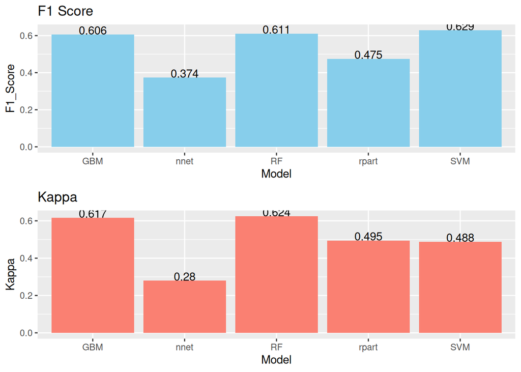

```r
# Calculamos el F1Score para cada modelo
rpart.f1 <- 2 * rpart.conf$byClass[, "Sensitivity"] * rpart.conf$byClass[, "Pos Pred Value"] / (rpart.conf$byClass[, "Sensitivity"] + rpart.conf$byClass[, "Pos Pred Value"])
rf.f1 <- 2 * rf.conf$byClass[, "Sensitivity"] * rf.conf$byClass[, "Pos Pred Value"] / (rf.conf$byClass[, "Sensitivity"] + rf.conf$byClass[, "Pos Pred Value"])
gbm.f1 <- 2 * gbm.conf$byClass[, "Sensitivity"] * gbm.conf$byClass[, "Pos Pred Value"] / (gbm.conf$byClass[, "Sensitivity"] + gbm.conf$byClass[, "Pos Pred Value"])
svm.f1 <- 2 * svm.conf$byClass[, "Sensitivity"] * svm.conf$byClass[, "Pos Pred Value"] / (svm.conf$byClass[, "Sensitivity"] + svm.conf$byClass[, "Pos Pred Value"])
nnet.f1 <- 2 * nnet.conf$byClass[, "Sensitivity"] * nnet.conf$byClass[, "Pos Pred Value"] / (nnet.conf$byClass[, "Sensitivity"] + nnet.conf$byClass[, "Pos Pred Value"])
rpart.f1 <- mean(rpart.f1)
rf.f1 <- mean(rf.f1)
gbm.f1 <- mean(gbm.f1)
svm.f1 <- mean(svm.f1)
nnet.f1 <- mean(nnet.f1)

# Realizamos un gráfico de barras del accuracy y el Kappa de cada modelo
# Calculamos métricas de desempeño
perf_df <- data.frame(
    Model = factor(c("rpart", "RF", "GBM", "SVM", "nnet")),
    F1_Score = c(
        rpart.f1,
        rf.f1,
        gbm.f1,
        svm.f1,
        nnet.f1
    ),
    Kappa = c(
        rpart.conf$overall["Kappa"],
        rf.conf$overall["Kappa"],
        gbm.conf$overall["Kappa"],
        svm.conf$overall["Kappa"],
        nnet.conf$overall["Kappa"]
    )
)

# Creamos los dos gráficos
p_acc <- ggplot(perf_df, aes(x = Model, y = F1_Score)) +
    geom_col(fill = "skyblue") +
    geom_text(aes(label = round(F1_Score, 3)), vjust = 0) +
    labs(title = "F1 Score")

p_kappa <- ggplot(perf_df, aes(x = Model, y = Kappa)) +
    geom_col(fill = "salmon") +
    geom_text(aes(label = round(Kappa, 3)), vjust = 0) +
    labs(title = "Kappa")

# Unimos ambos gráficos en un mismo grid
grid.arrange(p_acc, p_kappa, nrow = 2)
```

Se puede observar como los modelos que mejor desempeño tienen son `rf`, `gbm` y `svm`, con un F1 Score superior a 0.6; aunque respecto al valor Kappa, destacan solo `gbm` y `rf`, con valores mayores a 0.6. Por el lado contrario tenemos la red neuronal y `rpart`, que tienen desempeños mucho menores. Es normal que `rpart` tenga un mal desempeño, ya que es un modelo muy simple. Por otro lado, la red neuronal es un tipo de modelo que no está diseñado para este tipo de problemas, es decir, se desenvuelve mucho mejor en casos con una gran cantidad de predictores y datos. Aquí, por el contrario, tenemos solo 9 predictores y se han tenido que eliminar una gran cantidad de datos debido al desbalanceo. Aún así, seguramente con hiperparámetros más exigentes como mayor número de capas, unidades y epochs la red neuronal podría haber tenido un desempeño cercado o igual al Random Forest y GBM.

Aún así, tanto por simplicidad como por desempeño Random Forest y GBM son los mejores modelos para predecir el nivel de contaminación por PM2.5. Además, permiten conocer la importancia de los predictores. Vamos a visualizar esto último, de forma que podamos ver una jerarquía en las variables.

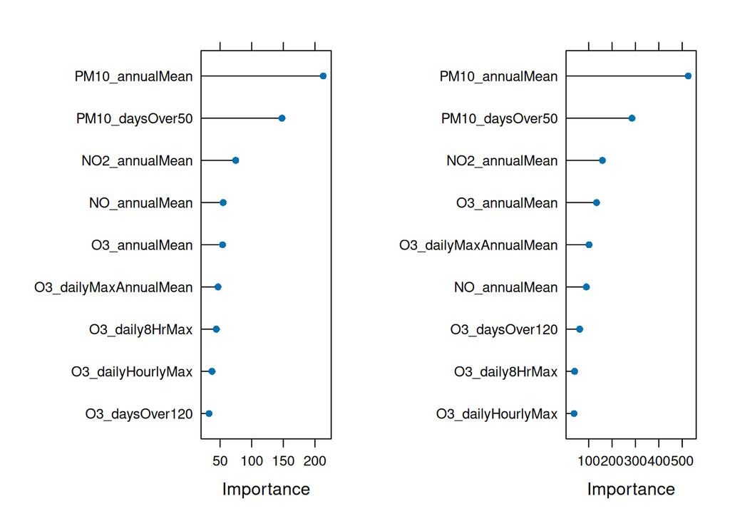

```r
# Calculamos la importancia de las variables predictoras
vi.rf <- varImp(rf.cv, scale = FALSE)
vi.gbm <- varImp(gbm.cv, scale = FALSE)

# Represetamos estas importancias con un grid
grid.arrange(
    plot(vi.rf),
    plot(vi.gbm),
    nrow = 1
)
```

Se observa en el gráfico superior que las variables más importantes en los dos modelos son las partículas PM10, luego NO2, y ya después se pone en duda si O3 o NO, aunque queda claro que son las partículas menos significativas. Por otro lado, se ve como las medias anuales suelen estar por encima que la cantidad de días u horas por encima de cierto umbral (a excepción de `PM10_daysOver50`, que como se vio en gráficos anteriores es una variable muy correlacionada con la contaminación de PM2.5).

# 4 Conclusiones

Finalmente, vamos a analizar todo lo que se ha visto en la gráfica.

Respecto al dataset se ha visto que es de baja calidad, si lo que se quiere hacer es predecir la contaminación por PM2.5. Esto se debe a que sus datos están altamente desbalanceados, además de que los datos de contaminación se concentran únicamente en 3 años, lo cuál indica una mala calidad a la hora de medir. Lo bueno del dataset es que apenas tiene datos faltantes o inválidos, suponiendo menos de un 3% del total. Además, el tener poca cantidad de predictores lo hace asequible a la hora de interpretar las variables, su significado y su importancia en los modelos.

Tras hacer los modelos y compararlos, se ha llegado a la conclusión que los mejores modelos para predecir la contaminación por PM2.5 son Random Forest y GBM, tanto por su eficacia como por su simpleza y facilidad de comprensión. La red neuronal, por muy potente que sea, al estar en una situación de pocos predictores y pocos datos (debido a la criba del balanceo) no se ha tenido un buen desempeño.

Con toda esta información y la que se ha visto a lo largo de la práctica podemos finalmente responder a las preguntas planteadas en la práctica: